# split_markers.Rmd

Mary Fisher, Eily Allan

2022-01-07

# Description

In between cutadapt and dada2, it’s necessary to split sequencing runs by marker so dada2 is only using one marker at a time. That way can customize the amount to trim in dada2 by marker.

*Originally written 7/29/2021, Eily Allen*

# Set up

User directories

```r
# where is the trimmed fastq output from cutadapt?
cutadapt_outdir <- "test-lane-1/data/cutadapt/noprimers"

# what is the root directory for the marker-specific subfolders?
split_outdir <- "test-lane-1/data/cutadapt"
```

parameters - in this script, only the run number.

```r
params <- data.frame(run.num=6)
```

# Split primer-trimmed fastq files by marker

use the pattern to sort out the files - `^` means “starts with” so we can use that to separate by marker

```r
fastq_noprimers_folder <- paste0(here(cutadapt_outdir))

BF3_files <- list.files(path = fastq_noprimers_folder, pattern = "^Locus_BF3_BF3", full.names = T)
L_files <- list.files(path = fastq_noprimers_folder, pattern = "^Locus_Leray_Leray", full.names = T)
LXT_files <- list.files(path = fastq_noprimers_folder, pattern = "^Locus_LerayXT_LXT", full.names = T)
```

now create subfolders for each marker

```r
dir.create(here(split_outdir, "BF3"))
dir.create(here(split_outdir, "Leray"))
dir.create(here(split_outdir, "LerayXT"))
```

and now move the files (which we already have listed out)

```r
file.move(BF3_files, here(split_outdir, "BF3"))
file.move(L_files, here(split_outdir, "Leray"))
file.move(LXT_files, here(split_outdir, "LerayXT"))
```

# Split metadata files

Now we should also split the sequencing metadata file by marker to use as input into dada2.

Read in the sequencing metadata file produced by cutadapt.

```r
cutadapt_output_metadata_all <- read_csv(paste0(fastq_noprimers_folder, "/output.metadata.csv"))
```

split up the sample / file info based on marker, and write the new dataframes to separate csv files

```r
cutadapt_output_metadata_BF3 <- filter(cutadapt_output_metadata_all, Locus == "BF3")
cutadapt_output_metadata_L <- filter(cutadapt_output_metadata_all, Locus == "Leray")
cutadapt_output_metadata_LXT <- filter(cutadapt_output_metadata_all, Locus == "LerayXT")

# write them all to csv files
write.csv(cutadapt_output_metadata_BF3, here(split_outdir, "BF3", "cutadapt_output_metadata_BF3.csv"), row.names=FALSE)
write.csv(cutadapt_output_metadata_L, here(split_outdir, "Leray", "cutadapt_output_metadata_Leray.csv"), row.names=FALSE)
write.csv(cutadapt_output_metadata_LXT, here(split_outdir, "LerayXT", "cutadapt_output_metadata_LerayXT.csv"), row.names=FALSE)
```

# Check cutadapt output

**How do the number of reads / sample change between the raw sequencing data, and the cutadapt-processed data??**

This is the first time I’m running this script, so I’m going to check the cutadapt output with Eily’s output, for the samples that were run by both of us.

Eily’s metadata to match sample ids with sample numbers

```r
ea_metadat <- read_csv(here("test-lane-1/data", "metadata-input-MF-test_fix.csv")) %>%
  separate(col=file1, into=c("id1","id2"), sep="_S", remove=FALSE)
ea_metadat %<>% mutate(id1=ifelse(id2=="peedVacNegative", "BF3_SpeedVacNegative",id1)) %>%
  dplyr::select(Sample_name,id1,Locus,file1)
```

the raw sequencing data read counts that I got from the NW Genomics center

```r
raw_readdat <- read_csv(here("data/raw/qc","EGC-Salish-Sea_Lane-1_MiSeq-Stats.csv"))
```

Join the sample numbers to the raw read depth data

```r
raw_readdat %<>% left_join(ea_metadat, by=c("sample"="id1")) %>%
  filter(!is.na(Sample_name))
```

## BF3

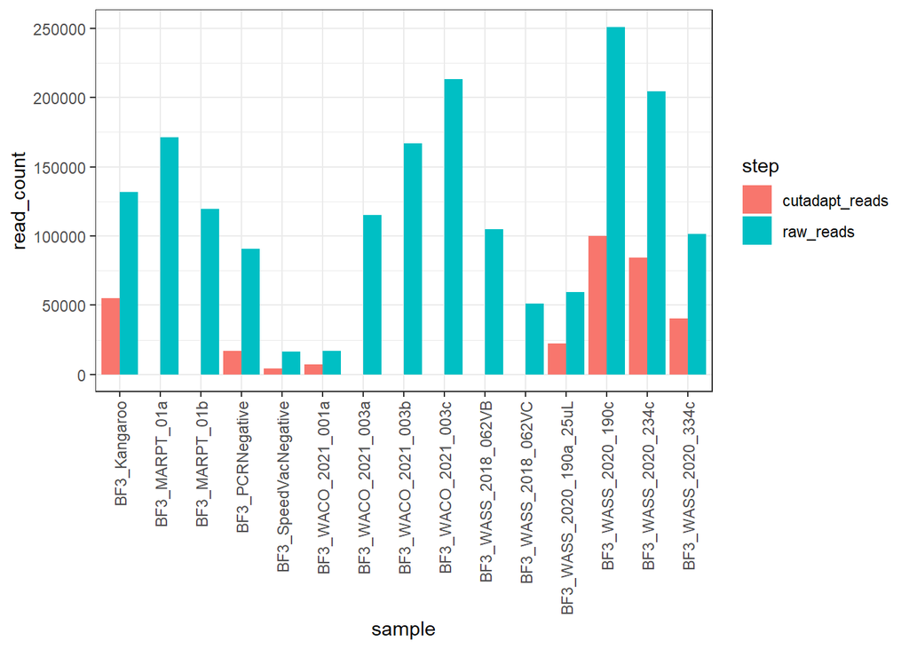

```r
bf3_ea_readdat <- read_csv(here("test-lane-1/data/BF3", "ASV_table.csv"))

bf3_ea_readdat %<>% left_join(raw_readdat, by=c("Sample_name", "Locus")) %>%
  group_by(Sample_name, sample, total_reads_per_lane) %>%
  summarise(total_reads=sum(nReads)) %>%
  rename(raw_reads=total_reads_per_lane, cutadapt_reads=total_reads)
```

## Leray

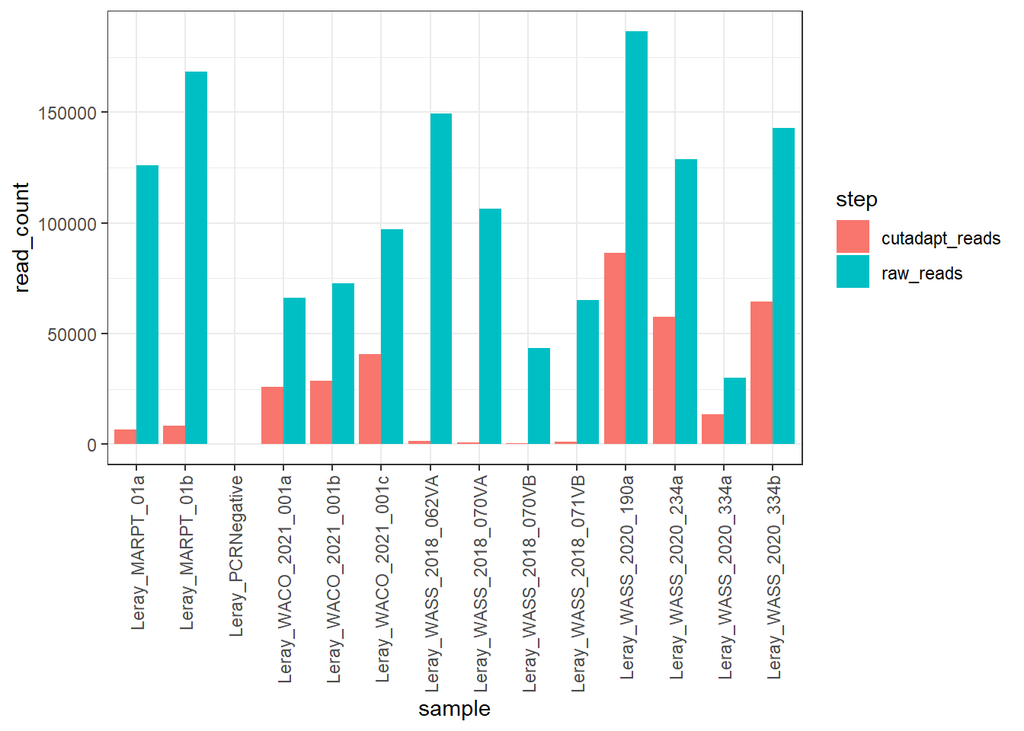

```r
l_ea_readdat <- read_csv(here("test-lane-1/data/Leray", "ASV_table.csv"))

l_ea_readdat %<>% left_join(raw_readdat, by=c("Sample_name", "Locus")) %>%
  group_by(Sample_name, sample, total_reads_per_lane) %>%
  summarise(total_reads=sum(nReads)) %>%
  rename(raw_reads=total_reads_per_lane, cutadapt_reads=total_reads)
```

## LerayXT

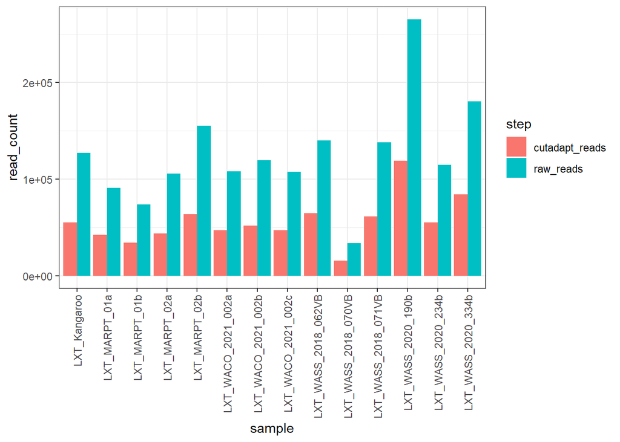

```r
lxt_ea_readdat <- read_csv(here("test-lane-1/data/LerayXT", "ASV_table.csv"))

lxt_ea_readdat %<>% left_join(raw_readdat, by=c("Sample_name", "Locus")) %>%
  group_by(Sample_name, sample, total_reads_per_lane) %>%
  summarise(total_reads=sum(nReads)) %>%
  rename(raw_reads=total_reads_per_lane, cutadapt_reads=total_reads)
```